# EMD_test

Jeffrey Chandler

2023-05-25

# EMD tests

The primary purpose of this document is to test multiple different cases of EMD and various algorithms for calculating EMD so that we can build upon our understanding of EMD. This document also includes other distance statistics for use in comparing pro’s and con’s qualitatively. As a line to remind yourself through this entire document **“The Earth Mover’s distance is simply the minimum cost to move from distribution P to Q”.** Another way to think about it is like childrens blocks. Your kid makes a wall, now they want to make a tower, what is the minimum number of blocks and the minimum moves to make for the child to make the the tower from the wall?

First we need to initialize the major functions These functions attempt to compute EMD using the EMD and Transport packages, along with the utilization of the “hungarian algorithm” to compute 1D EMD’s. I compute Hungarian Algorithm EMD both on the PDF and CDF to demonstrate the proper use of it. I also include multiple different distance and dissimilarity measures more for your information.

EMD_ICDF calculates the EMD over the ICDF when given a data frame of two CDF columns for distributions P and Q. It’s primary goal is to match percentiles with a corresponding value, then to calculate the absolute integral between those ICDF’s

ConvertToCDF is a helper function to turn two pdf’s into a dataframe of two cdfs

ks.test_JRC is my personal algorithm for calculating the Kolmogorov-Smirnov (KS) statistic. The base R implementation operates on sample data, so when we are working in PDF’s or CDF’s, ks.test breaks due to sample size problems. It in short finds the maximum absolute difference between CDF’s over the x axis

Hungarian Algorithm is what I found to perform EMD calculations and it matches the generalized form in the documentation for the Wasserstein package: https://www.rdocumentation.org/packages/transport/versions/0.12-1/topics/wasserstein1d and in multiple stack exchange lines that include studies: https://stats.stackexchange.com/questions/299365/how-to-measure-the-shift-between-two-cumulative-distribution-functions-cdfs, and https://stats.stackexchange.com/questions/603209/earth-mover-wasserstein-distance-for-ordinal-discrete-data. Normalized Hungarian Algorithm is the prior calculation divided by number of bins. I’ve built it to compute on PDF’s and CDF’s, to demonstrate which is the correct option

all_way_test is a large function who’s primary goal is to simply print a large table of different functions and implementations to confirm exactly what EMD functions are performing. For your reference, both `emdist` and `transport` use notation of A, wA, B, and wB for their inputs. A and B are “locations” while wA and wB are “weights”. This is important because we test swapping the two around to build a conceptual understanding of what those actually mean. I also added multiple other dissimilarity metrics so that we can generally see how they behave. They are:

- Kullback-Leibler (KL) Statistic with log = ln (nats) general KL statistic is $D_{KL} (P \| Q) = \sum_{x \in X}P(x)log \frac{P(x)}{Q(x)}$. Read as “the sum of the weighted log ratios from P to Q at every position x”
- KL Statistic with log = $log_2$ (bits)
- Symmetric KL. It is simply the sum of $D_{KL}(P \| Q)$ and $D_{KL}(Q \| P)$ because KL is not a symmetric function (as in $D_{KL}(P \| Q) \neq D_{KL}(Q \| P)$)
- Jensen-Shannon (JS) Divergence. A symmetric KL derived statistic. It is $\frac{1}{2}(D_{KL} (P \|M) +\frac{1}{2}(D_{KL} (Q \|M)$ where M is the average of P and Q: $M = \frac{P+Q}{2}$
- JS distance is simply the sqare root of JS Divergence
- KS statistic is the “maximum absolute difference between CDFs” $D_n = sup_x|F_n(x) - F(x)|$ where $F_n(x) and F(x)$ are the CDF functions describing P and/or Q, respectively. $sup_x$ is the “supremum” defined formally as the “least upper bound of a partially ordered set”. For example, the supremum of $\{ 1,2,3 \} = 3$, the maximum of a set.

```r
pkgs <- c("tidyverse", "emdist", "ggpattern", "transport", "FamilyRank",
          "Compositional", "philentropy", "MASS", "reshape2", "ggExtra", "terra", "viridisLite")
invisible(lapply(pkgs, library, character.only = T))
```

[output not shown]

```r
EMD_ICDF <- function(df,factors,du,p){
  f1 <- vector(length = 1/du)
  f2 <- vector(length = 1/du)
for(i in 1:(1/du)){
     u <- i*du

     f1[i] <-factors[which.min(abs(df$dist1 - u))]
     f2[i] <-factors[which.min(abs(df$dist2 - u))]
}
  emd <- sum(abs(f1-f2)^p*du)^(1/p)
  return(emd)
}
convertToCDF <- function(dist1_pdf, dist2_pdf,dx){
  dist1_pdf <- dist1_pdf %>%
                group_by(val)%>%
                summarise(rel = sum(dense))%>%
                dplyr::select(rel)%>%
                as.vector() %>%
                unname()%>%unlist()

  dist2_pdf <- dist2_pdf %>%
                group_by(val)%>%
                summarise(rel = sum(dense))%>%
                dplyr::select(rel) %>%
                as.vector() %>%
                unname() %>%unlist()

  dist1_cdf <-dist1_pdf
  dist2_cdf <- dist2_pdf
  for(i in 2:length(dist1_pdf)){
    dist1_cdf[i] <- dist1_pdf[i]+dist1_cdf[i-1]
    dist2_cdf[i] <- dist2_pdf[i]+dist2_cdf[i-1]
    }
  dist1_cdf <- dist1_cdf*dx
  dist2_cdf <- dist2_cdf*dx


  df <- data.frame(dist1 = dist1_cdf, dist2 = dist2_cdf)
  return(df)
}
ks.test_JRC <- function(dist1_pdf,dist2_pdf,dx){
  df <- convertToCDF(dist1_pdf,dist2_pdf,dx)
  absdiff <- abs(df[,1]-df[,2])
  return(max(absdiff))
}

hungarian_algo <- function(dist1, dist2, normalized = F, pdf =T, dx){
  if(pdf == T){
    df <- convertToCDF(dist1, dist2,dx)
  }else{
    df <- data.frame(dist1 = dist1$dense, dist2 = dist2$dense)
  }

  difference <- df$dist1-df$dist2
  absDifference <- abs(difference)
  emd <- sum(absDifference)*dx
  if(normalized == T){
    emd <- emd/length(dist1)
  }

  return(emd)
}

all_way_test <- function(dist1_pdf, dist2_pdf, factors,dx){


  numeric_factors <- as.numeric(factors)

  dist1_df <- data.frame(val = factors, dense = dist1_pdf)
  dist2_df <- data.frame(val = factors, dense = dist2_pdf)

  emd_hungarian_algo <- hungarian_algo(dist1_df,dist2_df,pdf = F,dx=dx)
  normalized_emd_hungarian_algo <- emd_hungarian_algo/length(unique(factors))
  emd_hungarian_algo_ascdf <- hungarian_algo(dist1_df,dist2_df, dx = dx)
  normalized_emd_hungarian_algo_ascdf <- emd_hungarian_algo_ascdf/length(unique(factors))


  emd_emdist_valuesByLocation <- emdist::emdw(dist1_pdf, factors, dist2_pdf,factors)
  emd_emdist_locationByValue <- emdist::emdw(factors, dist1_pdf, factors, dist2_pdf)
  emd_emdist_mat <- emd(cbind(dist1_pdf,factors),cbind(dist2_pdf, factors))

  #EMD already coerces your values into numerics. I have checked this
  #the code is here if you want to check yourself
 # emd_emdist_valuesByLocation_num <- emdw(dist1_pdf, numeric_factors, dist2_pdf,numeric_factors)
  #emd_emdist_locationByValue_num <- emdw(numeric_factors, dist1_pdf, numeric_factors, dist2_pdf)

  emd_wasserstein <-transport::wasserstein1d(dist1_pdf, dist2_pdf)
  emd_wasserstein_weightsFactors <-transport::wasserstein1d(dist1_pdf, dist2_pdf, 1,numeric_factors, numeric_factors)
  emd_wasserstein_weightsDists <-transport::wasserstein1d(numeric_factors, numeric_factors, 1, dist1_pdf, dist2_pdf)


  Pq<-rbind(dist1_pdf, dist2_pdf)*dx
  Qp <- rbind(dist2_pdf,dist1_pdf)*dx
  m <- .5*(dist1_pdf+dist2_pdf)
  Pm <- rbind(dist1_pdf, m)*dx
  Qm <- rbind(dist2_pdf, m)*dx

  KL_nats <-KL(Pq, unit = "log")
  KL_bits <- KL(Pq)
  KL_symmetric <-KL(Pq)+KL(Qp)
  JS_met <- .5*KL(Pm)+.5*KL(Qm)
  JS_dist <- sqrt(JS_met)

  distribution_cdf <- convertToCDF(dist1_df,dist2_df,dx)
  dist1_cdf <- c(distribution_cdf[,1])
  dist2_cdf <- c(distribution_cdf[,2])
  KS_stat <- ks.test_JRC(dist1_df, dist2_df,dx)

  emd_inverse <- EMD_ICDF(distribution_cdf,factors,.001,1)


  names <- c(
             "Hungarian as CDF: ",
             "Normalized Hungarian as CDF: ",
             "EMD inverse method: ",
             "wasserstein probability = wa:",
             "emd probability = wa using emdw: ",
             "emd probability = wa using emd:  ",
             "KL Divergence, Nats: ",
             "KL Divergence, Bits: ",
             "KL Symmetric divergence: ",
             "JS Metric: ",
             "JS Distance: ",
             "KS Stat: ",
             "emd probability = a:",
             "wasserstein no weights:",
             "wasserstein probability = a:",
             "Hungarian Algorithim:",
             "Normalized Hungarian Algorithim:"
             #"emd values = a, numeric factors:", "
             #numeric factors:",
             )
  values <- c(
              emd_hungarian_algo_ascdf,
              normalized_emd_hungarian_algo_ascdf,
              emd_inverse,
              emd_wasserstein_weightsDists,
              emd_emdist_locationByValue,
               emd_emdist_mat,
              KL_nats,
              KL_bits,
              KL_symmetric,
              JS_met,
              JS_dist,
              KS_stat,
              emd_emdist_valuesByLocation,
              emd_wasserstein,
              emd_wasserstein_weightsFactors,
              emd_hungarian_algo,
              normalized_emd_hungarian_algo
              #emd_emdist_valuesByLocation_num,
              #emd_emdist_locationByValue_num,
              )
  values <- as.character(values)
  printing <- paste(names, values, sep = " ")
  return(printing)
}
```

## Initial testing, simple case:

This initial simple case is when I have a probability mass function defined from 1-6. Distribution P is a uniform distribution designed like rolling a dice. Distribution Q is a non symmetric adjustment to ensure symmetry doesn’t conflate results

```r
####test 1, simple demonstration, discrete case

factors <- as.factor(seq(1,6))

distribution1 <- c(rep(1/6,6))
distribution2 <- c(0,0,0.15,0.8,0.05,0)
dx = 1
first_test <- all_way_test(distribution1, distribution2, factors, dx = dx)
```

```
## Metric: 'kullback-leibler' using unit: 'log'; comparing: 2 vectors.
```

```
## Metric: 'kullback-leibler' using unit: 'log2'; comparing: 2 vectors.
## Metric: 'kullback-leibler' using unit: 'log2'; comparing: 2 vectors.
## Metric: 'kullback-leibler' using unit: 'log2'; comparing: 2 vectors.
## Metric: 'kullback-leibler' using unit: 'log2'; comparing: 2 vectors.
## Metric: 'kullback-leibler' using unit: 'log2'; comparing: 2 vectors.
```

Here are plots of the Hungarian Algorithm without CDF. I have 2 masses. I take the absolute difference, then sum up the masses

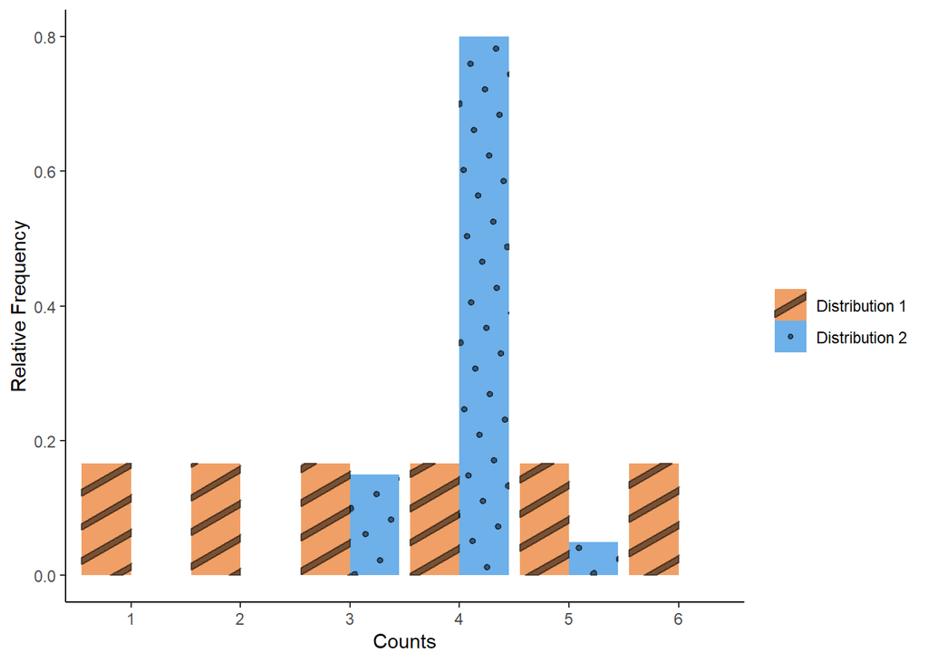

and here are the CMF versions of these

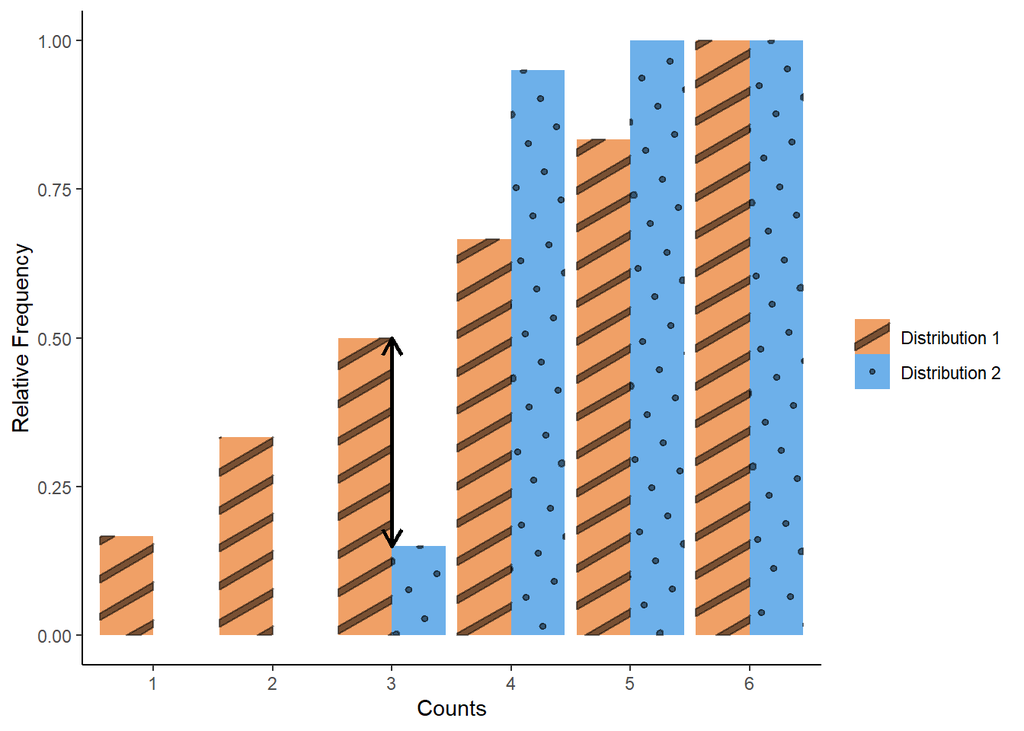

Here is the test to see how these algorithms compares

```r
first_test
```

```
##  [1] "Hungarian as CDF:  1.3"
##  [2] "Normalized Hungarian as CDF:  0.216666666666667"
##  [3] "EMD inverse method:  0.858"
##  [4] "wasserstein probability = wa: 1.3"
##  [5] "emd probability = wa using emdw:  1.30000007152557"
##  [6] "emd probability = wa using emd:   1.30000007152557"
##  [7] "KL Divergence, Nats:  4.81736923154941"
##  [8] "KL Divergence, Bits:  6.9499947004874"
##  [9] "KL Symmetric divergence:  8.65077348142937"
## [10] "JS Metric:  0.437008488230993"
## [11] "JS Distance:  0.661066175379585"
## [12] "KS Stat:  0.35"
## [13] "emd probability = a: 0.222222223877907"
## [14] "wasserstein no weights: 0.211111111111111"
## [15] "wasserstein probability = a: 0.222222222222222"
## [16] "Hungarian Algorithim: 1.26666666666667"
## [17] "Normalized Hungarian Algorithim: 0.211111111111111"
```

It’s clear that when I perform hungarian algorithm on the ECMF, i get the same value as when I plug the PMF into the weights for wasserstein and EMD. We can Also see that the first column of EMD SHOULD be the densities, because the first column = weights. The first question stemming from this is “what are weights and locations”. To check what swapping location and weights does I decided to try replicating the numbers. It’s a nightmare, first let’s plot the swapped PDFS

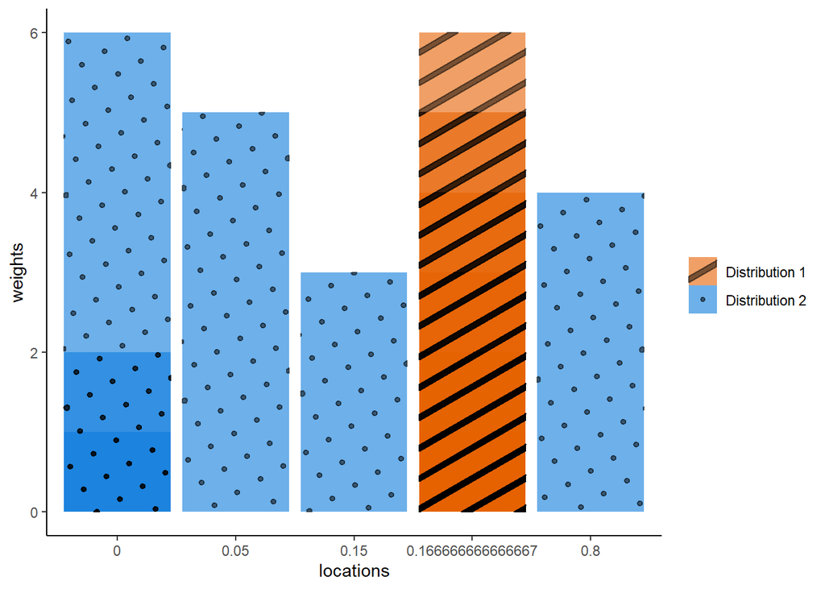

```r
df_1 <- data.frame(factors = factors, distribution1 = distribution1, distribution2 = distribution2)

df_1 <- df_1 %>%
  mutate(difference = distribution2-distribution1, absoluteDifference = abs(difference))
colors <- c("#E66100","#0C7BDC")
df_1_long <- df_1 %>%
  pivot_longer(c(distribution1, distribution2,), names_to = "distribution", values_to = "val")
df_1_long$distribution <- as.factor(df_1_long$distribution)

swappedplot <- ggplot(data = df_1_long )+
  geom_col_pattern(aes(y=as.numeric(factors), x = as.factor(val), fill = distribution, pattern = distribution),
                   position = 'dodge', alpha = .6, pattern_alpha = .5, pattern_color = "black",
                   pattern_fill = "black")+

  labs(x="locations", y = "weights")+
  scale_fill_manual(name='',
                    labels = c("Distribution 1", "Distribution 2"),
                     values=colors)+
  guides(fill = guide_legend(override.aes = list(pattern = c("stripe", "circle"))),
         pattern = "none") +
  theme_classic()
swappedplot
```

as you can see, this is really messed up. Distribution 1 only has 1/6 as a “location”, whilst distribution 2 has multiple locations. There is no consistent dx so this falls apart with the standard formulation. I must use the inverse notation given simply here https://www.bioconductor.org/packages/devel/bioc/vignettes/waddR/inst/doc/wasserstein_metric.html. Technically this is equivalent to the hungarian algorithm when p = 1, however is required when dx is inconsistent or p >1. This has a benefit of selecting equidistant percentiles which can always be inferred no matter the value you input

```r
df_swapped_long <- df_1_long %>%
  group_by(distribution,val)%>%
  summarise(n = n()) %>%
      mutate(rel = n/sum(n))
df1_swapped_pdf <- df_swapped_long%>%
  filter(distribution=="distribution1")
df1_swapped_vals <- as.vector(df1_swapped_pdf$val)
df2_swapped_pdf <- df_swapped_long %>%
  filter(distribution == "distribution2")
df2_swapped_vals <- as.vector(df2_swapped_pdf$val)

df1_cdf <- vector(length = length(df1_swapped_vals))
df2_cdf <- vector(length = length(df2_swapped_vals))
df1_cdf[1] <-df1_swapped_pdf$rel[1]
df2_cdf[1] <- df2_swapped_pdf$rel[1]
#for(i in 2:length(df1_swapped_vals)){
#  df1_cdf[i] <- df1_swapped_pdf$rel[i]+df1_cdf[i-1]

#}
for(i in 2:length(df2_swapped_vals)){
  df2_cdf[i] <- df2_swapped_pdf$rel[i]+df2_cdf[i-1]
}

df1_cdf <- as.data.frame(cbind(df1_swapped_vals,df1_cdf))
df2_cdf <- as.data.frame(cbind(df2_swapped_vals,df2_cdf))
```

Here is the EMDF

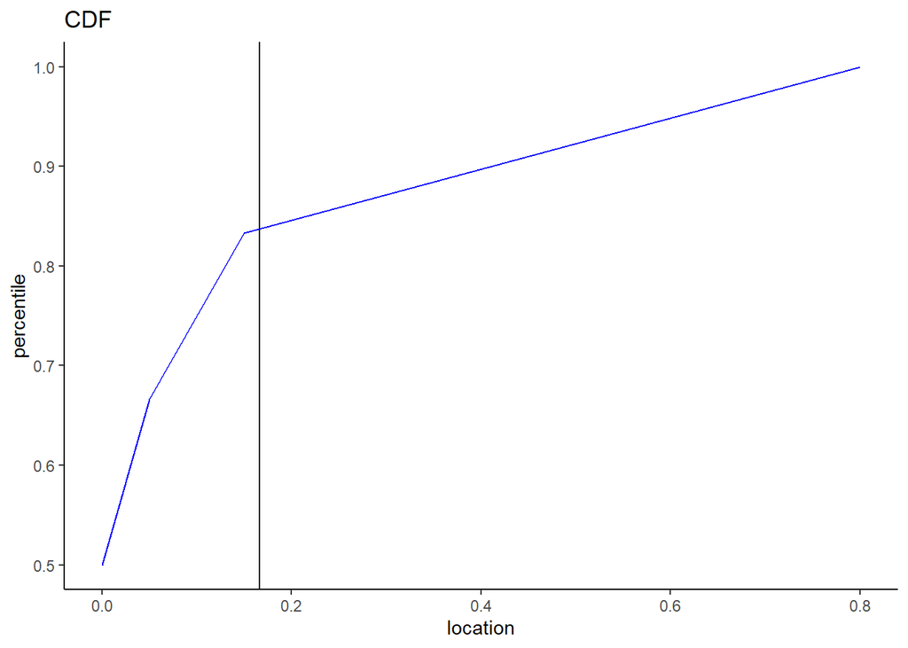

```r
ggplot()+
  geom_vline(xintercept = df1_cdf$df1_swapped_vals, df1_cdf, color = "black")+
  geom_line(aes(x=df2_swapped_vals, y = df2_cdf),df2_cdf, color = "blue")+
  ggtitle("CDF")+
  labs(x = "location",
       y = "percentile")+
  theme_classic()
```

Here is the inverse function.

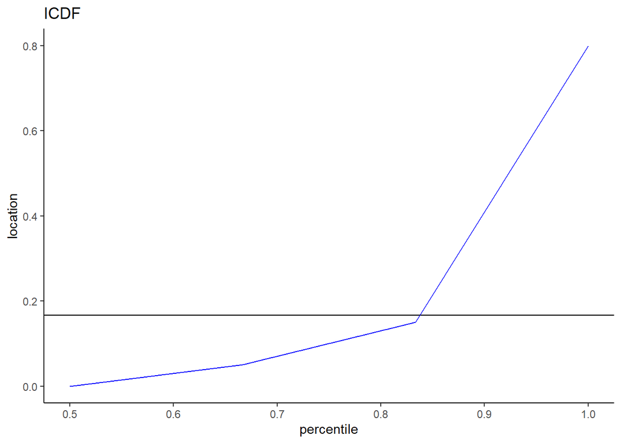

```r
ggplot()+
  geom_hline(yintercept = df1_cdf$df1_swapped_vals, df1_cdf, color = "black")+
  geom_line(aes(y=df2_swapped_vals, x = df2_cdf),df2_cdf, color = "blue")+
  ggtitle("ICDF")+
  labs(y = "location",
       x = "percentile")+
  theme_classic()
```

I set du (the percentile interval) to .001, then evaluate the inverse function at each. I sum the result and get the EMD.

```r
du = .001
p <-1
f1 <- vector(length = 1/du)
f2 <- vector(length = 1/du)
for(i in 1:(1/du)){
     u <- i*du

     f1[i] <-df1_swapped_vals[which.min(abs(df1_cdf$df1_cdf - u))]
     f2[i] <-df2_swapped_vals[which.min(abs(df2_cdf$df2_cdf - u))]
}
  emd <- sum(abs(f1-f2)^p*du)^(1/p)
emd
```

```
## [1] 0.1725167
```

The difference is simply based the exact formulation of the inverse CDF and choice of du. I’m comfortable that is what swapping weights and locations means, and I do not know what purpose it could possibly have.

Take home message. Weights are densities. Locations are coordinates corresponding to densities. (For those using MKDE, your output should be the densities, and your inputs to MKDE are the locations)

as a quick sanity check, I want to see if I half the density, but have two on the same location (what you can potentially see using the MKDE function) we reach the same answer

```r
factors <- as.factor(c(1,2,3,4,4,5,6))


distribution1 <- c(1/6,1/6,1/6,1/12,1/12,1/6,1/6)
distribution2 <- c(0,0,0.15,0.4,0.4,0.05,0)
dx = 1
second_test <- all_way_test(distribution1, distribution2, factors, dx = dx)
```

```
## Metric: 'kullback-leibler' using unit: 'log'; comparing: 2 vectors.
```

```
## Metric: 'kullback-leibler' using unit: 'log2'; comparing: 2 vectors.
## Metric: 'kullback-leibler' using unit: 'log2'; comparing: 2 vectors.
## Metric: 'kullback-leibler' using unit: 'log2'; comparing: 2 vectors.
## Metric: 'kullback-leibler' using unit: 'log2'; comparing: 2 vectors.
## Metric: 'kullback-leibler' using unit: 'log2'; comparing: 2 vectors.
```

```r
first_test
```

```
##  [1] "Hungarian as CDF:  1.3"
##  [2] "Normalized Hungarian as CDF:  0.216666666666667"
##  [3] "EMD inverse method:  0.858"
##  [4] "wasserstein probability = wa: 1.3"
##  [5] "emd probability = wa using emdw:  1.30000007152557"
##  [6] "emd probability = wa using emd:   1.30000007152557"
##  [7] "KL Divergence, Nats:  4.81736923154941"
##  [8] "KL Divergence, Bits:  6.9499947004874"
##  [9] "KL Symmetric divergence:  8.65077348142937"
## [10] "JS Metric:  0.437008488230993"
## [11] "JS Distance:  0.661066175379585"
## [12] "KS Stat:  0.35"
## [13] "emd probability = a: 0.222222223877907"
## [14] "wasserstein no weights: 0.211111111111111"
## [15] "wasserstein probability = a: 0.222222222222222"
## [16] "Hungarian Algorithim: 1.26666666666667"
## [17] "Normalized Hungarian Algorithim: 0.211111111111111"
```

```r
second_test
```

```
##  [1] "Hungarian as CDF:  1.3"
##  [2] "Normalized Hungarian as CDF:  0.216666666666667"
##  [3] "EMD inverse method:  0.632"
##  [4] "wasserstein probability = wa: 1.3"
##  [5] "emd probability = wa using emdw:  1.30000007152557"
##  [6] "emd probability = wa using emd:   1.30000007152557"
##  [7] "KL Divergence, Nats:  4.81736923154941"
##  [8] "KL Divergence, Bits:  6.9499947004874"
##  [9] "KL Symmetric divergence:  8.65077348142937"
## [10] "JS Metric:  0.437008488230993"
## [11] "JS Distance:  0.661066175379585"
## [12] "KS Stat:  0.35"
## [13] "emd probability = a: 0.133333340287209"
## [14] "wasserstein no weights: 0.133333333333333"
## [15] "wasserstein probability = a: 0.133333333333333"
## [16] "Hungarian Algorithim: 1.26666666666667"
## [17] "Normalized Hungarian Algorithim: 0.211111111111111"
```

Very similar results! That’s good.

If I look at graphing the CMFS, I see something very similar and get a similar result overall. Overall, having overlapping densities does get cleaned up in analysis.

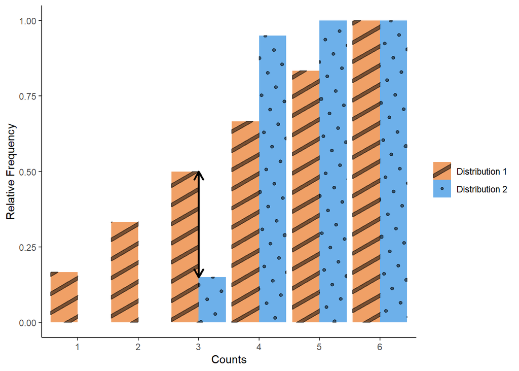

#### Shifting Distributions

This case is where I have a complete lack of overlap between distribution 1 and distribution 2, but I adjust them by multiples of six. Note: distribution 2 SHOULD be much farther in the second example than the first

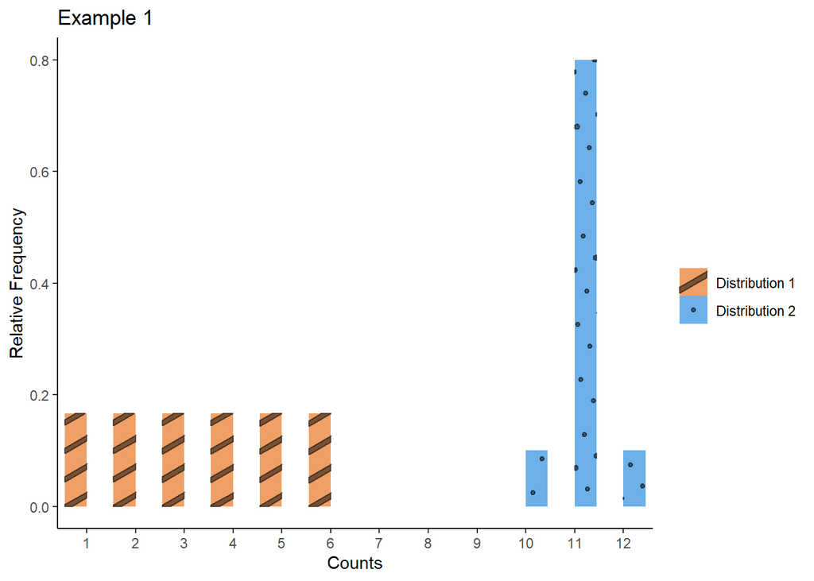

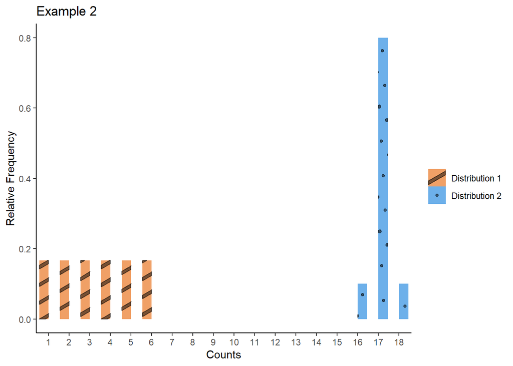

#### First Example

```r
factors <- factors <- as.factor(seq(1,12))
distribution1 <- c(rep(1/6,6),rep(0,6))
distribution2 <- c(rep(0,12-3),.1,.8,.1)
dx = 1
all_way_test(distribution1, distribution2, factors, dx = dx)
```

```
## Metric: 'kullback-leibler' using unit: 'log'; comparing: 2 vectors.
```

```
## Metric: 'kullback-leibler' using unit: 'log2'; comparing: 2 vectors.
## Metric: 'kullback-leibler' using unit: 'log2'; comparing: 2 vectors.
## Metric: 'kullback-leibler' using unit: 'log2'; comparing: 2 vectors.
## Metric: 'kullback-leibler' using unit: 'log2'; comparing: 2 vectors.
## Metric: 'kullback-leibler' using unit: 'log2'; comparing: 2 vectors.
```

```
##  [1] "Hungarian as CDF:  7.5"
##  [2] "Normalized Hungarian as CDF:  0.625"
##  [3] "EMD inverse method:  7.014"
##  [4] "wasserstein probability = wa: 7.5"
##  [5] "emd probability = wa using emdw:  7.5"
##  [6] "emd probability = wa using emd:   7.5"
##  [7] "KL Divergence, Nats:  9.72116599574217"
##  [8] "KL Divergence, Bits:  14.0246779737157"
##  [9] "KL Symmetric divergence:  29.7123903532651"
## [10] "JS Metric:  1"
## [11] "JS Distance:  1"
## [12] "KS Stat:  1"
## [13] "emd probability = a: 0.113247863948345"
## [14] "wasserstein no weights: 0.105555555555556"
## [15] "wasserstein probability = a: 0.113247863247863"
## [16] "Hungarian Algorithim: 2"
## [17] "Normalized Hungarian Algorithim: 0.166666666666667"
```

#### Second Example

```r
factors <- factors <- as.factor(seq(1,18))
distribution1 <- c(rep(1/6,6),rep(0,12))
distribution2 <- c(rep(0,18-3),.1,.8,.1)
dx = 1
all_way_test(distribution1, distribution2, factors, dx = dx)
```

```
## Metric: 'kullback-leibler' using unit: 'log'; comparing: 2 vectors.
```

```
## Metric: 'kullback-leibler' using unit: 'log2'; comparing: 2 vectors.
## Metric: 'kullback-leibler' using unit: 'log2'; comparing: 2 vectors.
## Metric: 'kullback-leibler' using unit: 'log2'; comparing: 2 vectors.
## Metric: 'kullback-leibler' using unit: 'log2'; comparing: 2 vectors.
## Metric: 'kullback-leibler' using unit: 'log2'; comparing: 2 vectors.
```

```
##  [1] "Hungarian as CDF:  13.5"
##  [2] "Normalized Hungarian as CDF:  0.75"
##  [3] "EMD inverse method:  12.714"
##  [4] "wasserstein probability = wa: 13.5"
##  [5] "emd probability = wa using emdw:  13.5"
##  [6] "emd probability = wa using emd:   13.5"
##  [7] "KL Divergence, Nats:  9.72116599574217"
##  [8] "KL Divergence, Bits:  14.0246779737157"
##  [9] "KL Symmetric divergence:  29.7123903532651"
## [10] "JS Metric:  1"
## [11] "JS Distance:  1"
## [12] "KS Stat:  1"
## [13] "emd probability = a: 0.0820662751793861"
## [14] "wasserstein no weights: 0.0703703703703704"
## [15] "wasserstein probability = a: 0.082066276803119"
## [16] "Hungarian Algorithim: 2"
## [17] "Normalized Hungarian Algorithim: 0.111111111111111"
```

KL, JS, KS, and Hungarian Algorithm over PDF’s are where we lose the ability to differentiate example one from example two; this is for multiple reasons. KL and JS statistics particularly struggle with non overlapping distributions due to the usage of a Log ratio. if the target distribution contains a zero, we get a divide by zero error. The setup of the KL function inputs a tiny number to try to correct for that issue, however that leads to the next problem. KS exemplifies this problem the best, when there is complete disconnection from one distribution to the next, we cannot measure the degree of disconnection from point to point calculations like KL, JS, and KS. In the case of KS, ECDF’s that don’t overlap will always have a maximum disimilarity. The figure below shows that Q1 is at zero while P is at 1, and same goes from Q2, the maximum difference will always be 1. The reason EMD avoids this problem is because it is specifically measuring transport, which incorporates distance into the equation

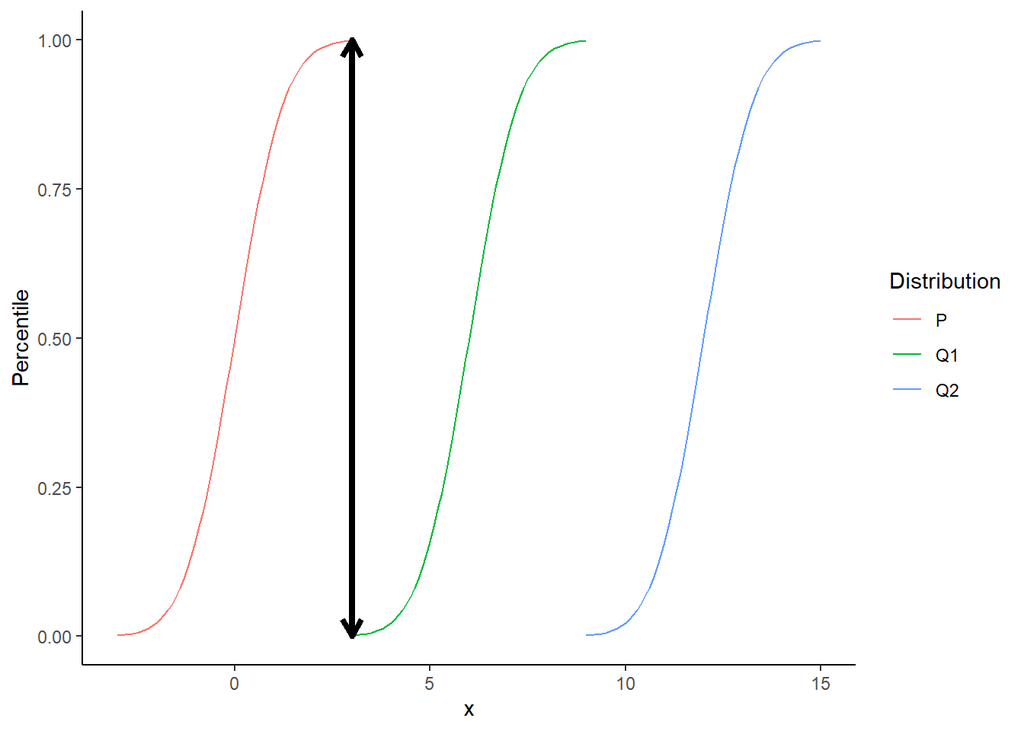

```r
x1 <- seq(-3,3,.1)
x2 <- seq(3,9,.1)
x3 <- seq(9,15,.1)

cnorm1 <- pnorm(x1, 0)
cnorm2 <- pnorm(x2, 6)
cnorm3 <- pnorm(x3, 12)


x <- c(x1,x2,x3)
cnorm <- c(cnorm1,cnorm2,cnorm3)

cnorm_df <- tibble(x = x, percentile = cnorm)%>%
  mutate(Distribution = ifelse(x == x1, "P",ifelse(x == x2, "Q1", "Q2")))

ggplot(cnorm_df,aes(x=x, y = percentile, color = Distribution))+
geom_line()+
  xlab("x")+
  ylab("Percentile")+
  geom_segment(x = x1[length(x1)],xend = x1[length(x1)], y = 0, yend = 1, color = "black", linewidth = 1.5,
               arrow = arrow(length = unit(0.03, "npc"),ends = "both"))+
  theme_classic()
```

## Continuous Example

### Unimodal case

Let’s apply what we know to simple unimodal Gausian distributions to extend this into continuous data further

```r
x <- seq(-3,3,.1)
dx <- x[2]-x[1]
dist1 <- dnorm(x)
dist2 <- dnorm(x, 0, .25)
all_way_test(dist1, dist2, x, dx)
```

```
## Metric: 'kullback-leibler' using unit: 'log'; comparing: 2 vectors.
```

```
## Metric: 'kullback-leibler' using unit: 'log2'; comparing: 2 vectors.
## Metric: 'kullback-leibler' using unit: 'log2'; comparing: 2 vectors.
## Metric: 'kullback-leibler' using unit: 'log2'; comparing: 2 vectors.
## Metric: 'kullback-leibler' using unit: 'log2'; comparing: 2 vectors.
## Metric: 'kullback-leibler' using unit: 'log2'; comparing: 2 vectors.
```

```
##  [1] "Hungarian as CDF:  0.599900416241158"
##  [2] "Normalized Hungarian as CDF:  0.00983443305313374"
##  [3] "EMD inverse method:  0.5931"
##  [4] "wasserstein probability = wa: 0.594639765334903"
##  [5] "emd probability = wa using emdw:  0.594190299510956"
##  [6] "emd probability = wa using emd:   0.594190299510956"
##  [7] "KL Divergence, Nats:  5.925934955594"
##  [8] "KL Divergence, Bits:  8.54931697306602"
##  [9] "KL Symmetric divergence:  9.87305367264932"
## [10] "JS Metric:  0.364542492906777"
## [11] "JS Distance:  0.603773544391254"
## [12] "KS Stat:  0.292442829584668"
## [13] "emd probability = a: Inf"
## [14] "wasserstein no weights: 0.190645094001328"
## [15] "wasserstein probability = a: 0.0813772235137267"
## [16] "Hungarian Algorithim: 1.1629350734081"
## [17] "Normalized Hungarian Algorithim: 0.0190645094001329"
```

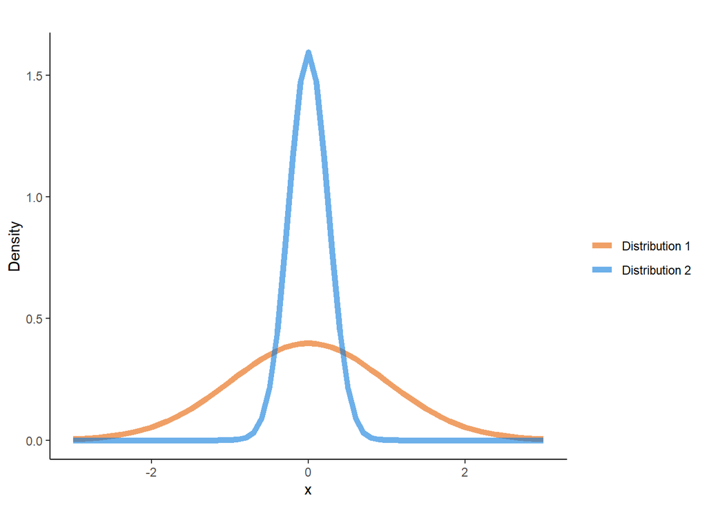

Here are the CDFS and absolute Difference plots

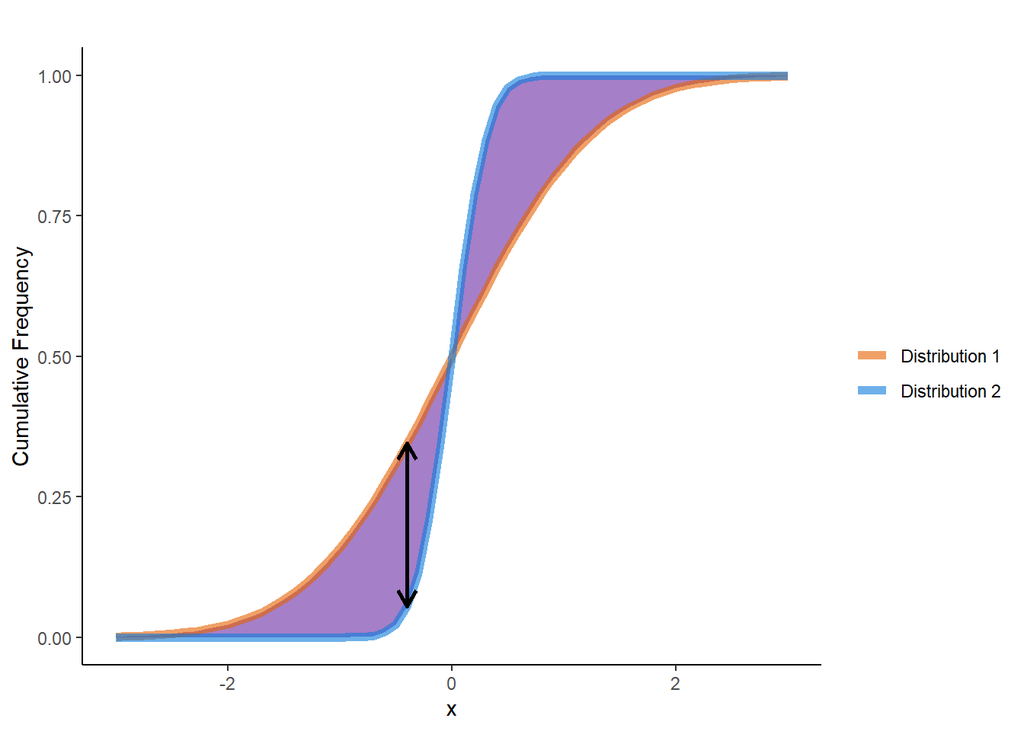

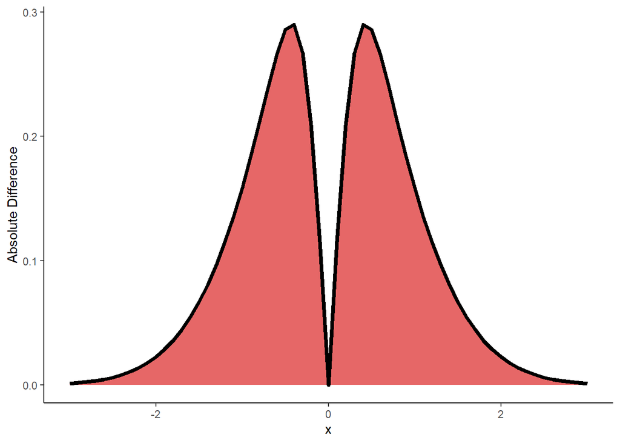

Overall, nothing to note. We see the same agreement behind the same implementations of EMD. What I’m noticing, is normalizing EMD may not be the best option. It doesn’t make sense to normalize when we are modeling how density moves within a distribution. That is real movement within a real distribution. Normalizing is not really necessary$^1$.

### Bimodal

Let’s do the same with a bimodal distribution.

```r
x <- seq(-3,3,.1)
dx = .1
dist1 <- dnorm(x)
dist1_cdf <- pnorm(x)
dist2a <- rbinorm(1000000, -1.5, 1.5, .7, .7,.5)

cdf <- ecdf(dist2a)
dist2_cdf <- cdf(x)
dist2_kde <- tibble(val = dist2a) %>%
    mutate(bin = cut(val, breaks = x)) %>%
    group_by(bin) %>%
    drop_na() %>%
    summarise(n = n()) %>%
    mutate(rel = n/sum(n)/dx)%>%
    dplyr::select(rel)


all_way_test(dist1[-1], dist2_kde$rel, x[-1],dx = dx)
```

```
## Metric: 'kullback-leibler' using unit: 'log'; comparing: 2 vectors.
```

```
## Metric: 'kullback-leibler' using unit: 'log2'; comparing: 2 vectors.
## Metric: 'kullback-leibler' using unit: 'log2'; comparing: 2 vectors.
## Metric: 'kullback-leibler' using unit: 'log2'; comparing: 2 vectors.
## Metric: 'kullback-leibler' using unit: 'log2'; comparing: 2 vectors.
## Metric: 'kullback-leibler' using unit: 'log2'; comparing: 2 vectors.
```

```
##  [1] "Hungarian as CDF:  0.681728153012046"
##  [2] "Normalized Hungarian as CDF:  0.0113621358835341"
##  [3] "EMD inverse method:  0.6798"
##  [4] "wasserstein probability = wa: 0.687470212208998"
##  [5] "emd probability = wa using emdw:  0.683315932750702"
##  [6] "emd probability = wa using emd:   0.683315932750702"
##  [7] "KL Divergence, Nats:  0.590268486059168"
##  [8] "KL Divergence, Bits:  0.851577417630598"
##  [9] "KL Symmetric divergence:  1.67572038704435"
## [10] "JS Metric:  0.191357695980809"
## [11] "JS Distance:  0.43744450617285"
## [12] "KS Stat:  0.23077058424455"
## [13] "emd probability = a: 0.160259068012238"
## [14] "wasserstein no weights: 0.0516828614356803"
## [15] "wasserstein probability = a: 0.0871511931657363"
## [16] "Hungarian Algorithim: 0.883018738314997"
## [17] "Normalized Hungarian Algorithim: 0.0147169789719166"
```

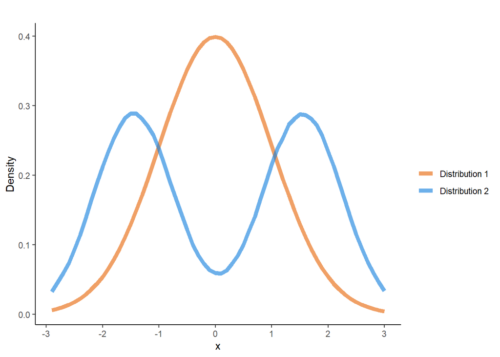

Here are the CDF’s and absolute difference plots

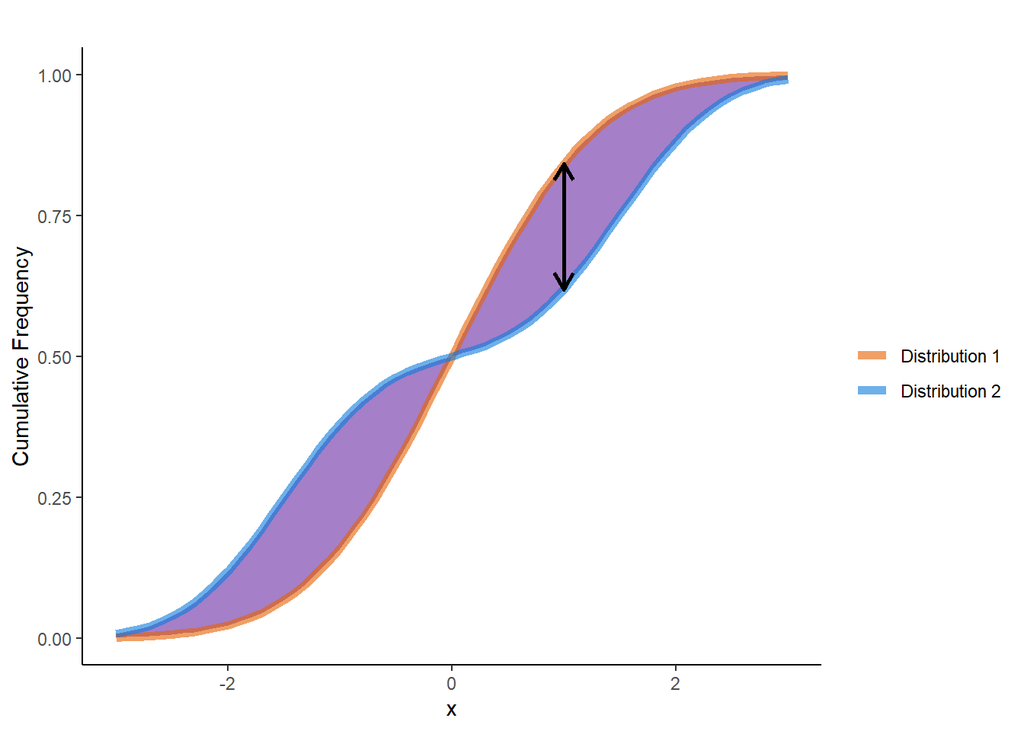

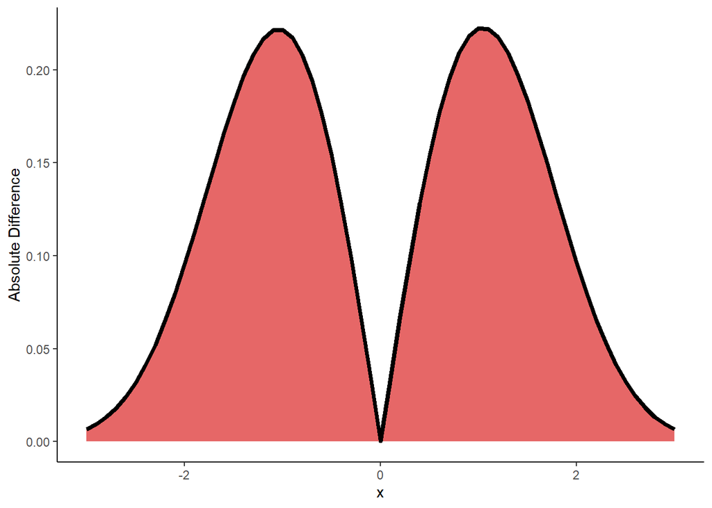

Overall, nothing is screaming out oddly here, however, in order to make the next step to multiple dimensions, we need to readjust our thinking slightly. Let’s contextualize the problem less as “the absolute differences between CDF’s” towards “let’s solve for the minimum cost to move distribution P to distribution Q” like in our main definition. This is necessary because the 1D case has special properties that allow us to work with a simple one dimensional integral, however in higher dimensions we enter the realm of “optimal transport theory”

First thing we should do is model the cost from a given position in A, to every position in B. This can be conceptualized as a cost matrix (C), where axis 1 is “From P” and axis 2 is “To Q”

for the bivariate problem above, lets compute C as this (using absolute distance, which is equivalent to 1-wasserstein)

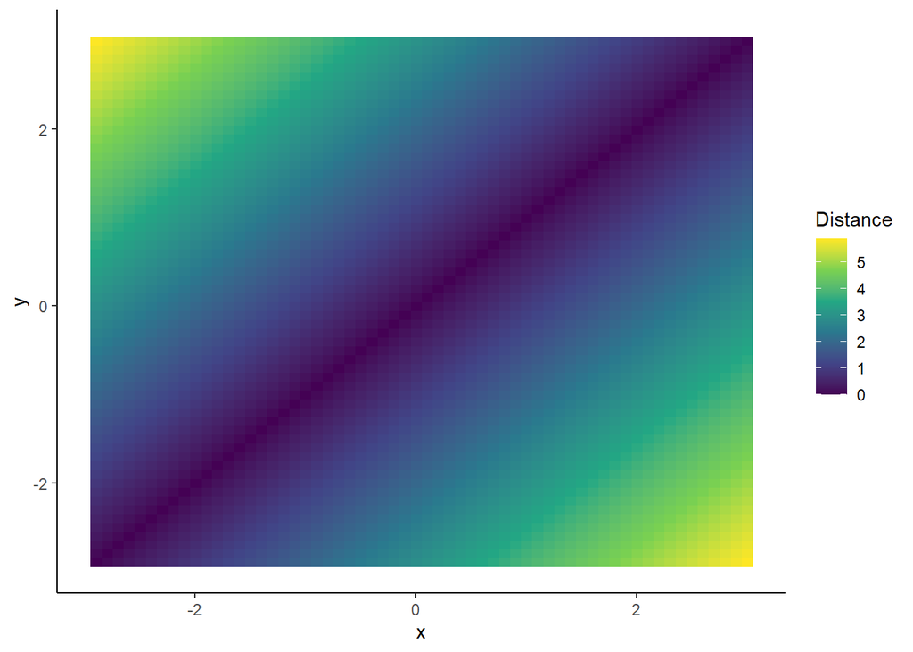

```r
n <- length(x)-1
C <- matrix(nrow = n, ncol = n)
for(i in 1:n){
  for(j in 1:n){
    C[i,j] = sqrt((x[i]-x[j])^2)
  }
}
dimnames(C) <- list(x = x[-1], y = x[-1])
C_df <- melt(C, value.name = "intensity")

plot <- ggplot(C_df) +
  geom_raster(aes(x = x, y = y, fill = intensity))+
  scale_fill_viridis_c()+
  labs(fill="Distance")+
  theme_classic()
plot
```

This cost matrix makes sense. 0’s along the 1:1 line because that’s no movement. As you go out diagonally, the cost increases

We can overlay the distributions we created just so we can reference them. We can see that if we move “earth” from the center of A to the sides of B could be seen as moving from y at zero to -2 on the x, where the distance is about 2

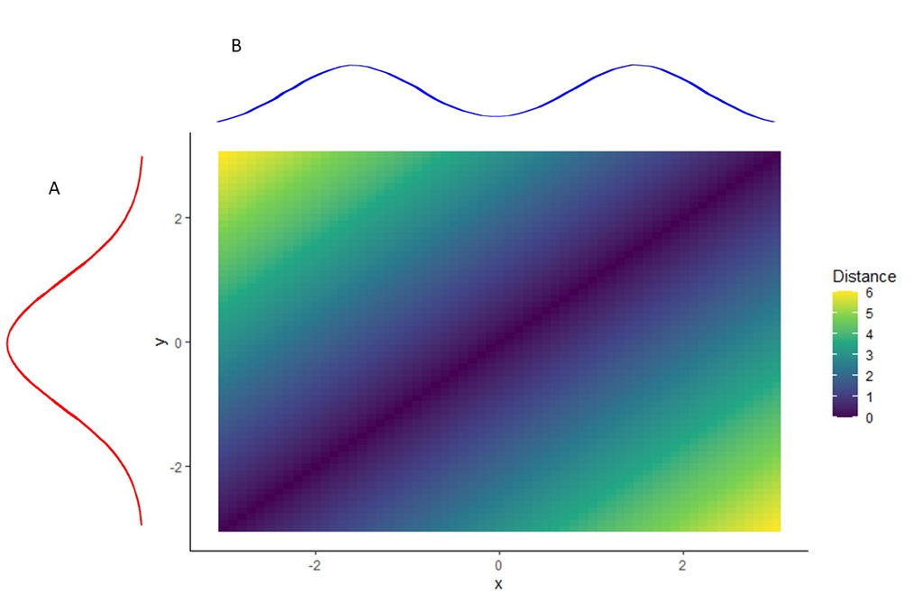

```r
knitr::include_graphics("C:/Users/JChandler/Desktop/Work/EMDTests/MarPlot.jpg")
```

Now we must create a solver to compute the “optimal transport solution” from distribution P to distribution Q with the cost matrix.

This is a linear programming solver. We are trying to minimize the sum of unknown Transportation plan (T) * C subject to the conditions that $T1 = p$ (1 is a matrix of ones equal in length to T), $T^\top 1 = q$, and $T \ge 0$. These constraints ensure that ALL of P moves to ALL of q (essentially conservation of mass) and that we do not look for negative solutions. The full math formulation is

$$cost = <T,C> = \sum_{i = 1}^{n}{
\sum_{j=1}^{m} {T_{ij} C_{ij}}}$$

$$\begin{array}{ll}
\text{minimize T,} & <T, C>\\
\text{subject to} & T 1 = p, T^\top 1 = q, T \ge 0 \\
\end{array}$$

```r
Ap <- matrix(0,nrow = n, ncol = n*n)
Aq <- matrix(0,nrow = n, ncol = n*n)
z <- matrix(0,nrow=n,ncol=n)
z[,1] <- 1
#C <- vector(length = n)
#for(i in 1:n){

#    C[i] = sqrt((x[i]-x[1])^2)

#}


for(i in 1:n){
  Ap[i,] <- c(t(z))
  Aq[i,] <- c(z)
  z[,i] <- 0
  if(i == n){
    z[,1] <- 1
  }else{
  z[,i+1] <- 1
  }
}

dist1 <- dist1[-1]
dist1 <- dist1/sum(dist1)
dist2 <- unname(unlist(dist2_kde))
dist2 <- dist2/sum(dist2)
#Ap <- Ap[1:(n-1),]
B <- c(dist1,dist2)
A <- rbind(Ap,Aq)
dir <- rep("=",length(B))

solved <- lpSolve::lp("min",c(C),A, dir,B)
solved
```

```
## Success: the objective function is 0.6895416
```

BOOYAH!!!!! That is nearly dead ON with what we calculated earlier.

Here is the Optimal Transport (OT) map that we calculated. the EMD is the sum of the OT map multiplied by the cost matrix. The OT map is simply “where do we move in the cheapest way” and the cost matrix is “what is the cost to move at this position”. EMD then, is the **“minimum total cost to move from P to Q”.**

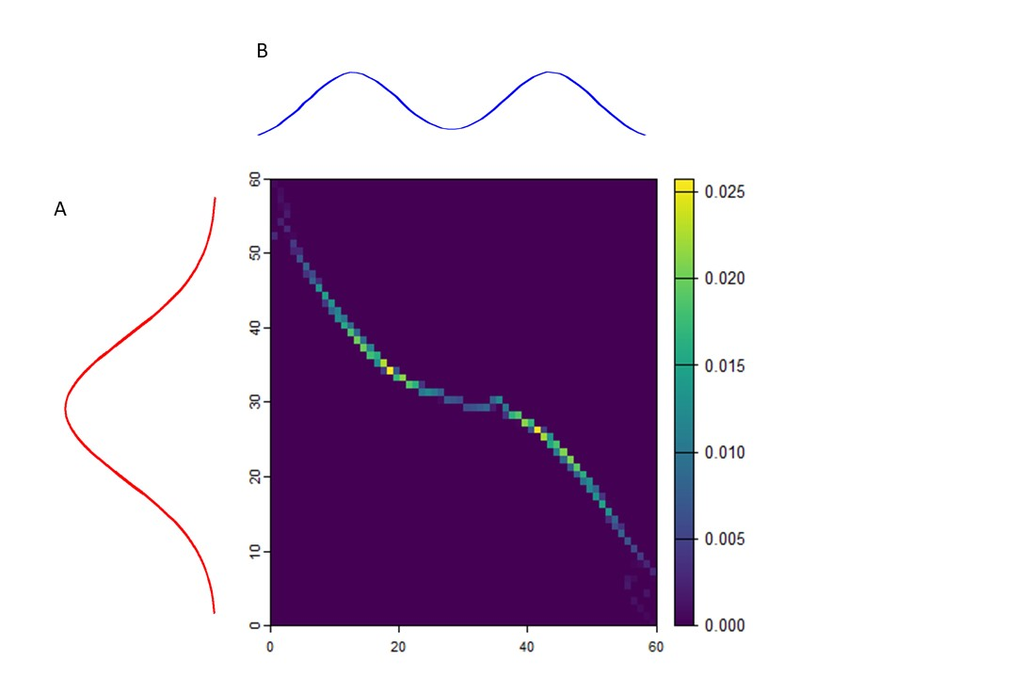

This makes sense. We move the center peak out to the edges in order to go from the unimodal model to the bimodal model

Let’s just see what this looks like with a shift in distribution. I’m just taking the second distribution and splitting it in half then comparing the halves.

```
## Success: the objective function is 2.959882
```

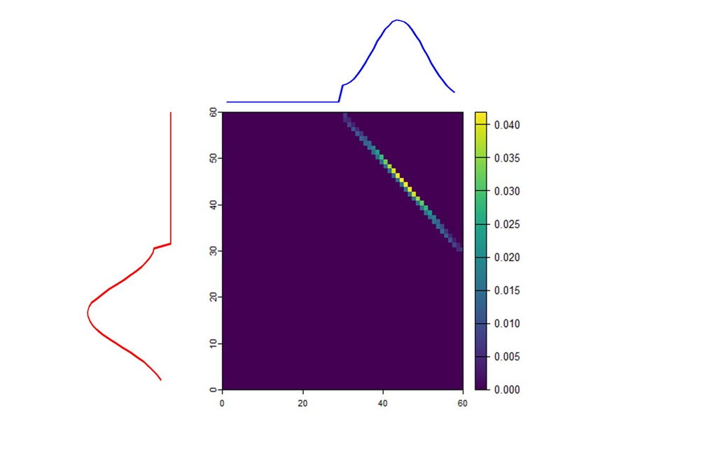

This makes more sense. Shifting from left to right would result in lots of data moving to that top right corner. large distance, but uniformly.

Just to sanity check, what’s the EMD

```r
TC <- sum(t*C)
wass <- wasserstein1d(x[-1],x[-1],1,p$y,q$y)
em <-emdw(x[-1],p$y,x[-1],q$y)
```

```
## [1] "OT map * Cost = 2.95988206500934"
```

```
## [1] "Wasserstein Function = 2.95988206500934"
```

```
## [1] "EMDW Function = 2.95696353912354"
```

## Multivariate

### Primer

To talk about wasserstein metric in greater than two dimensions, we expand the optimal transport perspective more. When we look at the Optimal transport map for the 1D case, you can see there is a clear pattern in how it transports “earth”. That property is why we can use the simpler framework in 1D, that property does not persist in two dimensions. However, movement is intuitive when we remember **minimum total cost to move from P to Q”.** The difficulty is in the model formulation.

Let’s start with creating two multivariate datasets

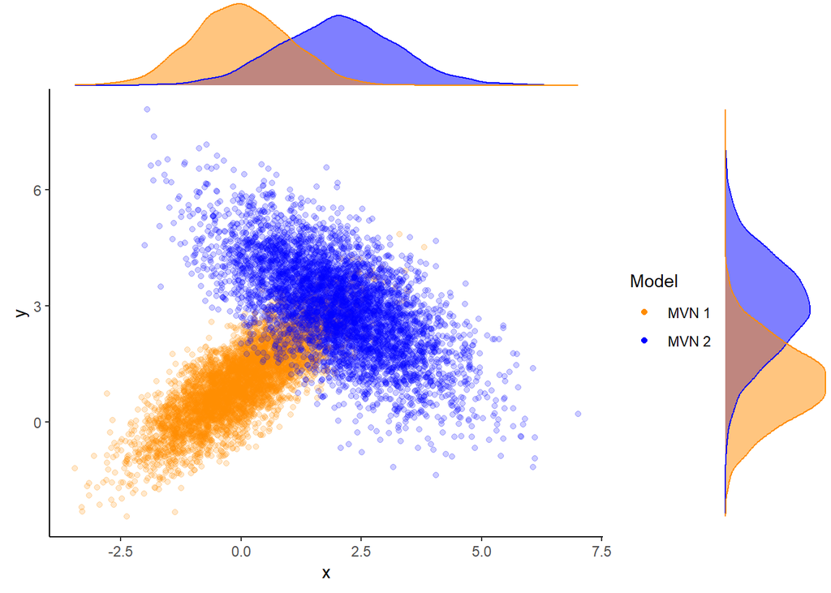

```r
df_rmvn1 <- as.data.frame(mvrnorm(n = 5000, c(0,1),matrix(c(1,.8,.8,1),nrow = 2, ncol = 2)))
df_rmvn2 <- as.data.frame(mvrnorm(n = 5000, c(2,3),matrix(c(1.5,-.95,-.95,1.5),nrow = 2, ncol = 2)))

df_rmvn1_locs <-df_rmvn1
df_rmvn2_locs <-df_rmvn2

df_rmvn1$Model <- "MVN 1"
df_rmvn2$Model <- "MVN 2"
df_rmvn <- rbind(df_rmvn1,df_rmvn2)

cols <- c("MVN 1" = "darkorange", "MVN 2" = "blue")
df_rmvn_plot <- ggplot(df_rmvn, aes(x = V1, y = V2, color = Model))+
  geom_point(alpha =.2)+
  guides(colour = guide_legend(override.aes = list(alpha = 1)))+

  scale_color_manual(values = cols)+
  xlab("x")+
  ylab("y")+

  theme_classic()

ggMarginal(df_rmvn_plot,groupColour = T, groupFill = T, type = "density")
```

Here are the point plots with the marginal distributions.

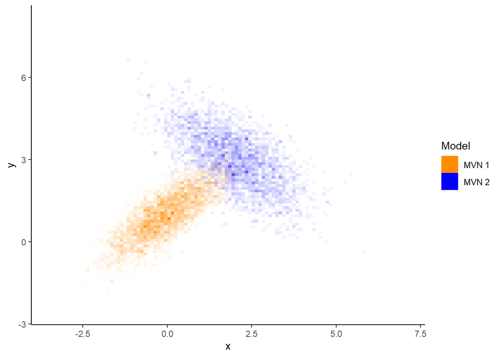

```r
df_1_kde <- data.frame(kde = mkde(as.matrix(df_rmvn1[,c(1,2)])))
df_2_kde <- data.frame(kde = mkde(as.matrix(df_rmvn2[,c(1,2)])))

df_1_kde4pgrid <- cbind(df_1_kde, as.matrix(df_rmvn1[,c(1,2)])) %>%
  arrange(V1, V2)
df_2_kde4pgrid <- cbind(df_2_kde, as.matrix(df_rmvn2[,c(1,2)])) %>%
  arrange(V1,V2)


df_1_kde$Model <- "MVN 1"
df_2_kde$Model <- "MVN 2"
df_kde<- rbind(df_1_kde,df_2_kde)
df_kde <- cbind(df_kde, df_rmvn[,c(1,2)])

df_kde_plot <- ggplot(df_kde, aes(x = V1, y = V2, fill = Model))+
  geom_bin2d(aes(alpha = after_stat(count)),binwidth = c(0.1,0.1))+
  guides(alpha = "none")+
  scale_fill_manual(values = cols)+

  scale_alpha_continuous(range=c(0,1))+
  xlab("x")+
  ylab("y")+
  theme_classic()

df_kde_plot
```

Here is the same but as a 2D density plot

Now we can compute the cost matrix in 1D

```r
density_1 <- matrix(0, ncol = length(x_ticks), nrow = length(y_ticks))
density_2 <- density_1
#locs_array <- array(dim = c(length(y_ticks),length(x_ticks),2))



for(i in 1:(length(x_ticks)-1)){
  for(j in 1:(length(y_ticks)-1)){

    x_min <- x_ticks[i]
    x_max <- x_ticks[i+1]
    y_min <- y_ticks[j]
    y_max <- y_ticks[j+1]

    #locs_array[j,i,1] <- x_min
    #locs_array[j,i+1,1] <- x_max
    #locs_array[j,i,2] <- y_min
    #locs_array[j+1,i,2] <- y_max

    density_1[j,i] <-length(which(df_rmvn1_locs$V1>x_min & df_rmvn1_locs$V1 < x_max & df_rmvn1_locs$V2 >y_min & df_rmvn1_locs$V2<y_max))
    density_2[j,i] <- length(which(df_rmvn2_locs$V1>x_min & df_rmvn2_locs$V1 < x_max & df_rmvn2_locs$V2 >y_min & df_rmvn2_locs$V2<y_max))
  }
}
density_1_sum <- sum(density_1)
density_2_sum <- sum(density_2)

density_1 <- density_1/density_1_sum
density_2 <- density_2/density_2_sum

density_1_pg <- pgrid(density_1, boundary = bounds)#boundary sets the parameters for distance cost matrix
density_2_pg <- pgrid(density_2, boundary = bounds)
```

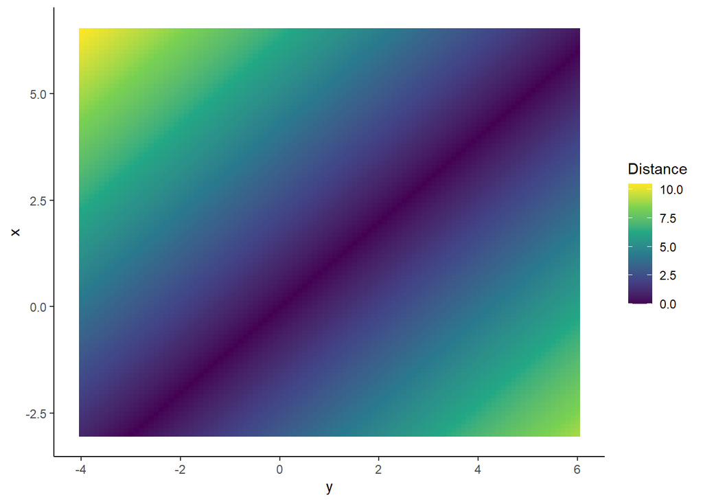

Here is a plot showing the cost matrix within a SINGLE dimension. Looks simple, however when we now compute those distances over the second dimension (so that we get true pairwise euclidean distances) we get this

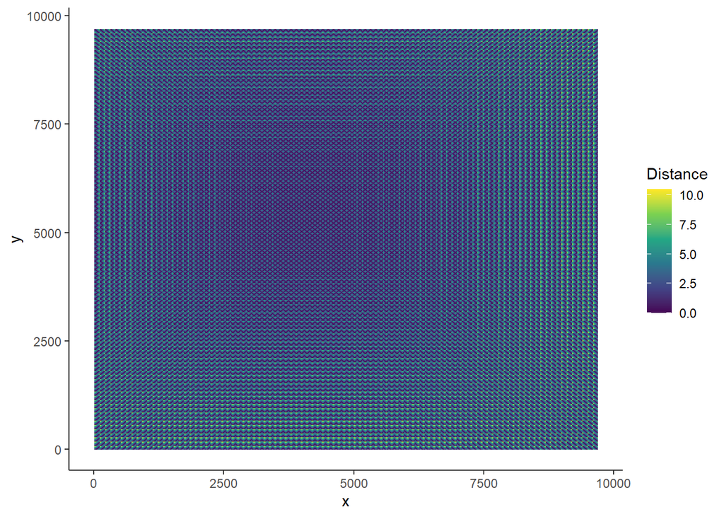

```r
C1_vec <- c(t(C1))
C2_vec <- C1
C <- matrix(0, nrow = length(C1_vec), ncol = length(C1_vec))
for(i in 1:length(C1_vec)){
  for(j in 1:length(C2_vec)){
    C[i,j] = sqrt((C1_vec[i]-C2_vec[j])^2)
  }
}

C_df <- melt(C, value.name = "intensity")
plot <- C_df %>% ggplot() +
  geom_raster(aes(x = Var1, y = Var2, fill = intensity))+
  scale_fill_viridis_c()+
  labs(fill="Distance")+
  xlab("x")+
  ylab("y")+
  theme_classic()
plot
```

```r
density_1_flat <- data.frame(x = rep(x_ticks, m),val = c(t(density_1)))
density_2_flat <- data.frame(x = rep(x_ticks, m),val = c(t(density_2)))
density_1_plot <-ggplot(density_1_flat, aes(x = x, y = val))+
  geom_col(fill = "darkorange")+
  ylab("Density")+
  theme_void()
#density_1_plot
density_2_plot <-ggplot(density_2_flat, aes(x = x, y = val))+
  geom_col(fill = "blue")+
  ylab("Density")+
  theme_void()
#density_2_plot
```

This is really difficult to understand. It’s basically pairwise distances from every point to every point.

*For additional information, here’s the marginal plots attached*

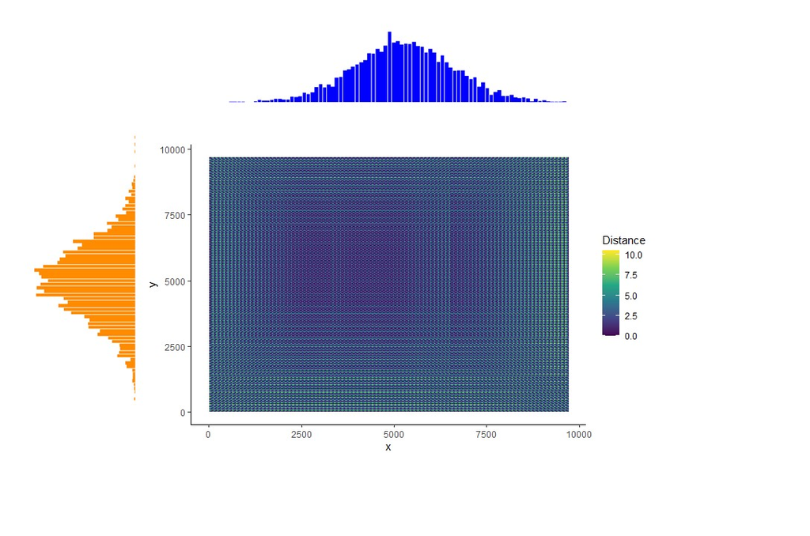

```r
knitr::include_graphics("C:/Users/JChandler/Desktop/Work/EMDTests/MarPlot_2D.jpg")
```

This gets messy really fast. The density of the cost matrix is $O(n^2)$ where n is the length of all dimensions. so a 1D line of 10 bins, turns into a 10 x 10 cost matrix. a 2d plane of 10 x 10 bins, becomes a 100 x 100 cost matrix. We are also flattening four dimensions into 2, which doesn’t help visualization. If you want to see what a transport plan over such a large matrix looks like, visit a primary inspiration for this write up http://alexhwilliams.info/itsneuronalblog/2020/10/09/optimal-transport/ The transport plans in 2D are not informative. However, implementing the transport plan and showing where distribution P moves to become distribution Q, is informative

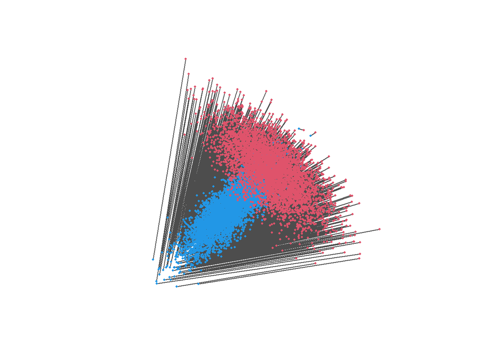

```r
dist1_pp <- pp(as.matrix(df_rmvn1[,c(1,2)]))
dist2_pp <- pp(as.matrix(df_rmvn2[,c(1,2)]))
transport_solvedPp<- transport(dist1_pp,dist2_pp, p = 1)
transport::plot.pp(dist1_pp,dist2_pp,transport_solvedPp, cex = .4)
```

```r
transport.solvedPg <- transport(density_1_pg, density_2_pg, p =1)
```

This is essentialy the optimal transport plan. We move points/densities from distribution P to distribution Q

here is the heatmap version of the prior, where the heat is how much density is moving through that area (aka “flow).

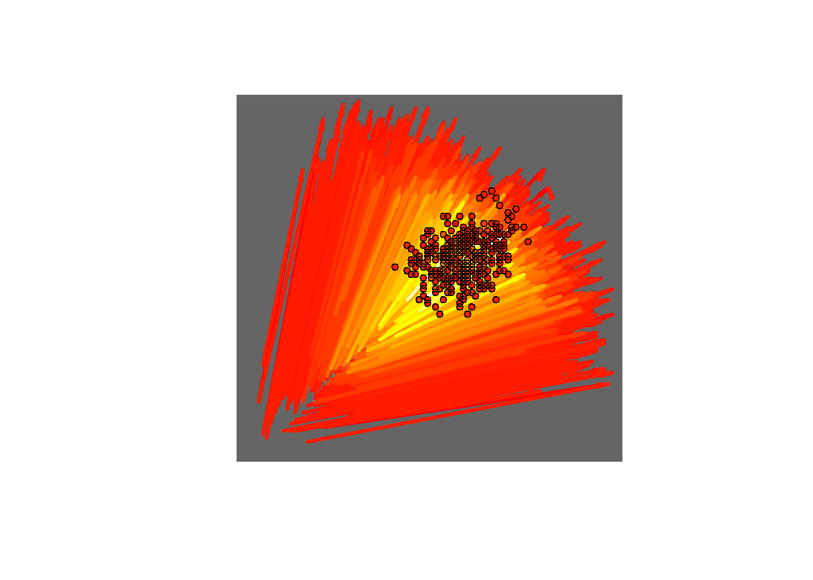

EMD calculated using the wasserstein package

```r
TC <- wasserstein(density_1_pg, density_2_pg, tplan = transport.solvedPg)
print(paste0("EMD = ", TC))
```

```
## [1] "EMD = 2.95155443618208"
```

As a sanity check, let’s see how the EMD function compares

```r
TC <- emd2d(density_1,density_2,xdist=.1,ydist=.1)
print(paste0("EMD = ", TC))
```

```
## [1] "EMD = 3.0098135471344"
```

Very similar.

Overall, I hope that helps you understand EMD far better than you have before. Remember, at the end of the day, it is the **minimum total cost to move from Q to P.**

$^1$I can see normalizing as potentially useful if we want to say something about “the proportion that changed”. because a 1x1 box has an area of 1, so the EMD could be directly interpreted as a proportion moved or “percent change”.